# Exercises Day 2

answered by Elliot Gardner, written by Richard Paquin Morel, adapted from exercises by Christina Maimone

2018-09-18

## Load the data

Load the `gapminder` dataset.

```r
gapminder <- read.csv(here::here("data","gapminder5.csv"), stringsAsFactors=FALSE)
```

```r
gapminder <- read.csv(here::here("data/gapminder5.csv"), stringsAsFactors=FALSE)
```

## If Statement

Use an if() statement to print a suitable message reporting whether there are any records from 2002 in the gapminder dataset. Now do the same for 2012.

Hint: use the `any` function.

```r
year <- 2002
if (any(gapminder$year == year)){
  print(paste0("There is data from ", year))
} else {
  print(paste0("There are not records from ", year))
}
```

```
## [1] "There is data from 2002"
```

```r
year <- 2012
if (any(gapminder$year == year)){
  print(paste0("There is data from ", year))
} else {
  print(paste0("There are not records from ", year))
}
```

```
## [1] "There are not records from 2012"
```

```r
year<-2002
if(any(gapminder$year == year)){
   print(paste("Record(s) for the year",year,"found."))
} else {
  print(paste("No records for year",year))
}
```

```
## [1] "Record(s) for the year 2002 found."
```

## Loop and If Statements

Write a script that finds the mean life expectancy by country for countries whose population is below the mean for the dataset

Write a script that loops through the `gapminder` data by continent and prints out whether the mean life expectancy is smaller than 50, between 50 and 70, or greater than 70.

```r
mean_pop <- mean(gapminder$pop)
countries <- unique(gapminder$country)
for (i in countries) {
  country_mean_pop <- mean(gapminder$pop[gapminder$country == i])

  if (country_mean_pop < mean_pop){
    country_mean_le <- mean(gapminder$lifeExp[gapminder$country == i])
    print(paste0("Country: ",i,", Mean Life Expectancy: ",country_mean_le))
  }
}
```

```
## [1] "Country: Afghanistan, Mean Life Expectancy: 37.4788333333333"
## [1] "Country: Albania, Mean Life Expectancy: 68.4329166666667"
## [1] "Country: Algeria, Mean Life Expectancy: 59.0301666666667"
## [1] "Country: Angola, Mean Life Expectancy: 37.8835"
## [1] "Country: Argentina, Mean Life Expectancy: 69.0604166666667"
## [1] "Country: Australia, Mean Life Expectancy: 74.6629166666667"
## [1] "Country: Austria, Mean Life Expectancy: 73.10325"
## [1] "Country: Bahrain, Mean Life Expectancy: 65.6056666666667"
## [1] "Country: Belgium, Mean Life Expectancy: 73.64175"
## [1] "Country: Benin, Mean Life Expectancy: 48.7799166666667"
## [1] "Country: Bolivia, Mean Life Expectancy: 52.5045833333333"
## [1] "Country: Bosnia and Herzegovina, Mean Life Expectancy: 67.7078333333333"
## [1] "Country: Botswana, Mean Life Expectancy: 54.5975"
## [1] "Country: Bulgaria, Mean Life Expectancy: 69.74375"
## [1] "Country: Burkina Faso, Mean Life Expectancy: 44.694"
```

[output cut: 100 more lines]

```r
overall_mean <- mean(gapminder$pop)

for (i in unique(gapminder$country)) {
   country_mean <- mean(gapminder$pop[gapminder$country==i])

   if (country_mean < overall_mean) {
     mean_le <- mean(gapminder$lifeExp[gapminder$country==i])
     print(paste("Mean Life Expectancy in", i, "is", mean_le))
   }
} # end for loop
```

```
## [1] "Mean Life Expectancy in Afghanistan is 37.4788333333333"
## [1] "Mean Life Expectancy in Albania is 68.4329166666667"
## [1] "Mean Life Expectancy in Algeria is 59.0301666666667"
## [1] "Mean Life Expectancy in Angola is 37.8835"
## [1] "Mean Life Expectancy in Argentina is 69.0604166666667"
## [1] "Mean Life Expectancy in Australia is 74.6629166666667"
## [1] "Mean Life Expectancy in Austria is 73.10325"
## [1] "Mean Life Expectancy in Bahrain is 65.6056666666667"
## [1] "Mean Life Expectancy in Belgium is 73.64175"
## [1] "Mean Life Expectancy in Benin is 48.7799166666667"
## [1] "Mean Life Expectancy in Bolivia is 52.5045833333333"
## [1] "Mean Life Expectancy in Bosnia and Herzegovina is 67.7078333333333"
## [1] "Mean Life Expectancy in Botswana is 54.5975"
## [1] "Mean Life Expectancy in Bulgaria is 69.74375"
## [1] "Mean Life Expectancy in Burkina Faso is 44.694"
```

[output cut: 100 more lines]

```r
conts <- unique(gapminder$continent)

for (i in conts){
  cont_mean_le <- mean(gapminder$lifeExp[gapminder$continent == i])

  if (cont_mean_le < 50) {
    print(paste0(i,"'s life expectancy is less than 50"))
  } else if (cont_mean_le <= 70) {
    print(paste0(i,"'s life expectancy is between 50 and 70"))
  } else {
    print(paste0(i,"'s life expctancy is greater than 70"))
  }
}
```

```
## [1] "Asia's life expectancy is between 50 and 70"
## [1] "Europe's life expctancy is greater than 70"
## [1] "Africa's life expectancy is less than 50"
## [1] "Americas's life expectancy is between 50 and 70"
## [1] "Oceania's life expctancy is greater than 70"
```

```r
lower_threshold <- 50
upper_threshold <- 70

for (i in unique(gapminder$continent)){
    tmp <- mean(gapminder$lifeExp[gapminder$continent==i])

    if (tmp < lower_threshold){
        print(paste("Average Life Expectancy in", i, "is less than", lower_threshold))
    }
    else if (tmp > lower_threshold & tmp < upper_threshold){
        print(paste("Average Life Expectancy in", i, "is between", lower_threshold, "and", upper_threshold))
    }
    else {
        print(paste("Average Life Expectancy in", i, "is greater than", upper_threshold))
    }

}
```

```
## [1] "Average Life Expectancy in Asia is between 50 and 70"
## [1] "Average Life Expectancy in Europe is greater than 70"
## [1] "Average Life Expectancy in Africa is less than 50"
## [1] "Average Life Expectancy in Americas is between 50 and 70"
## [1] "Average Life Expectancy in Oceania is greater than 70"
```

## Exercise: Write Functions

Create a function that given a data frame will print the name of each column and the class of data it contains. Use the gapminder dataset. Hint: Use `mode()` or `class()` to get the class of the data in each column. Remember that `names()` or `colnames()` returns the name of the columns in a dataset.

```r
names_and_types <-
  function(df) {
    cols <- colnames(df)
    for (i in cols){
      type <- class(df[[i]])
      print(paste0(i," is of type ", type))
    }
  }

names_and_types(gapminder)
```

```
## [1] "country is of type character"
## [1] "year is of type integer"
## [1] "pop is of type numeric"
## [1] "continent is of type character"
## [1] "lifeExp is of type numeric"
## [1] "gdpPercap is of type numeric"
```

```r
#Note: Some of these were taken or modified from https://www.r-bloggers.com/functions-exercises/
```

```r
data_frame_info <- function(df) {
  cols <- names(df)
  for (i in cols) {
    print(paste0(i, ": ", mode(df[, i])))
  }
}
data_frame_info(gapminder)
```

```
## [1] "country: character"
## [1] "year: numeric"
## [1] "pop: numeric"
## [1] "continent: character"
## [1] "lifeExp: numeric"
## [1] "gdpPercap: numeric"
```

Create a function that given a vector will print the mean and the standard deviation of a **vector**, it will optionally also print the median. Hint: include an argument that takes a boolean (`TRUE`/`FALSE`) operator and then include an `if` statement.

```r
mean_sd_median <-
  function(vec, print_median = FALSE){
    m <- mean(vec)
    std_dev <- sd(vec)

    if(print_median == TRUE){
      med <- median(vec)
      print(paste0("Median: ",m,", Standard Deviation: ", std_dev, ", Median: ",med))
    } else {
      print(paste0("Median: ",m,", Standard Deviation: ", std_dev))
    }
  }

mean_sd_median(gapminder$pop, TRUE)
```

```
## [1] "Median: 29601212.3251174, Standard Deviation: 106157896.746828, Median: 7023595.5"
```

```r
vector_info <- function(x, include_median=FALSE) {
  print(paste("Mean:", mean(x)))
  print(paste("Standard Deviation:", sd(x)))
  if (include_median) {
    print(paste("Median:", median(x)))
  }
}

le <- gapminder$lifeExp
vector_info(le, include_median = F)
```

```
## [1] "Mean: 59.4744393661972"
## [1] "Standard Deviation: 12.9171074152412"
```

```r
vector_info(le, include_median = T)
```

```
## [1] "Mean: 59.4744393661972"
## [1] "Standard Deviation: 12.9171074152412"
## [1] "Median: 60.7125"
```

## Analyzing the relationship

Use what you’ve learned so far to answer the following questions using the `gapminder` dataset. Be sure to include some visualizations!

1. What is the relationship between GDP per capita and life expectancy? Does this relationship change over time? (Hint: Use the natural log of both variables.)

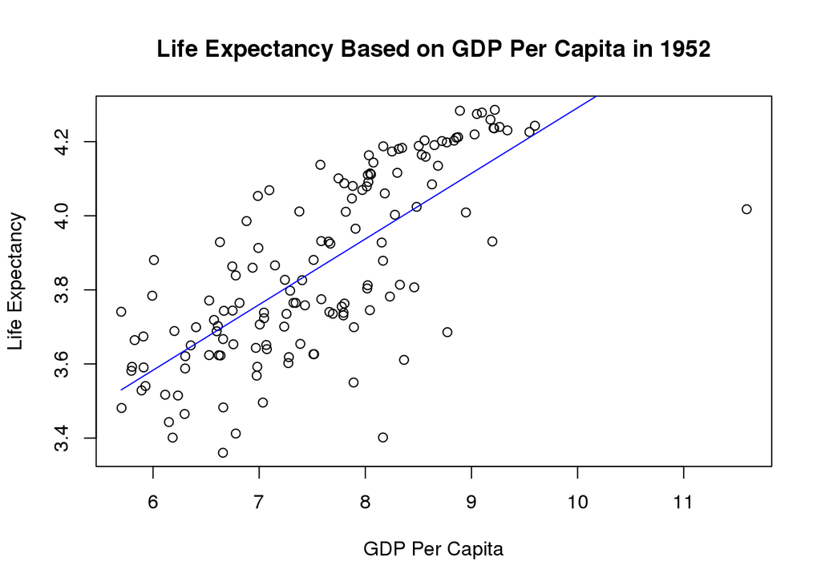

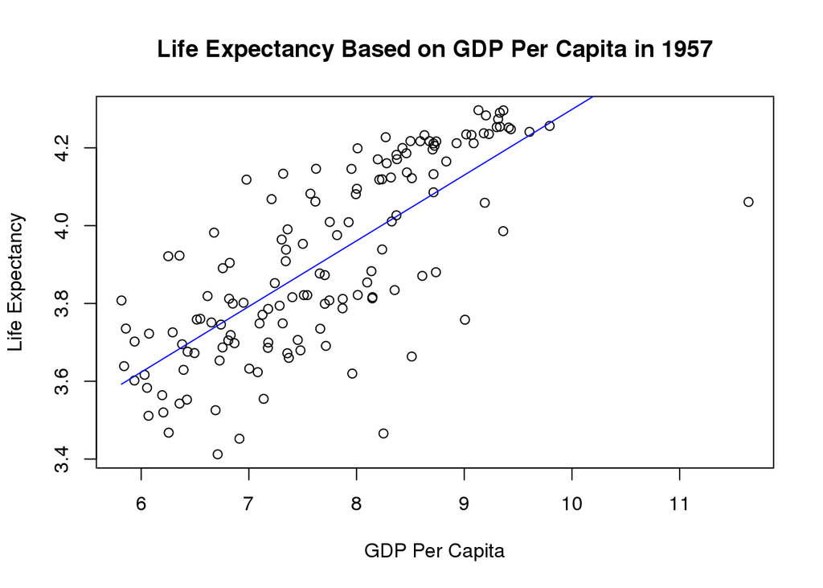

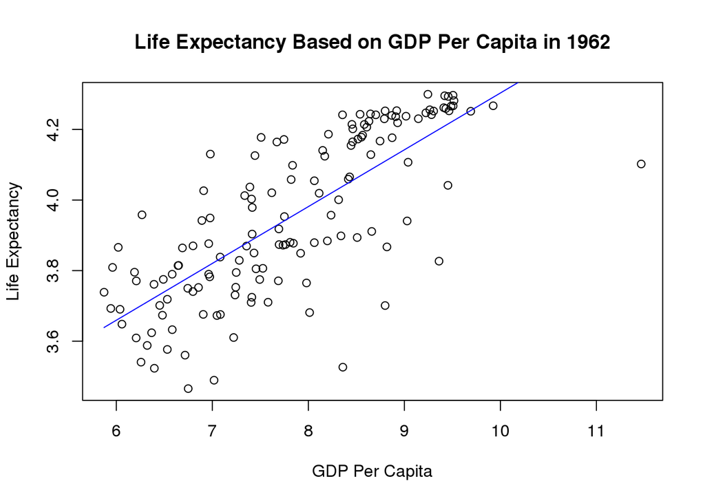

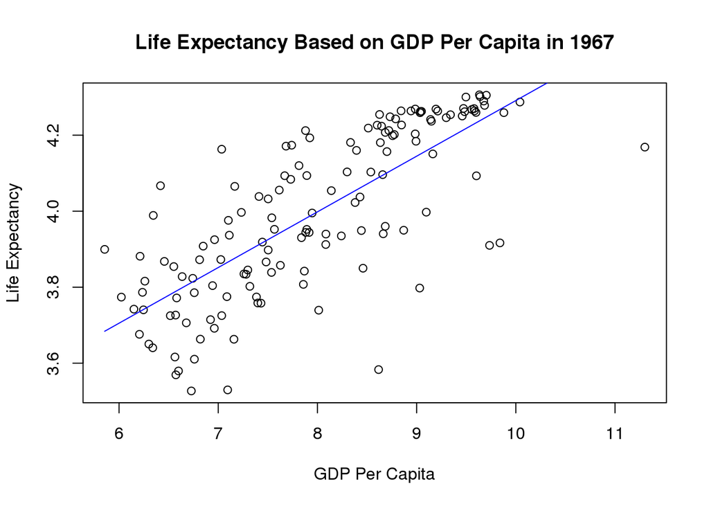

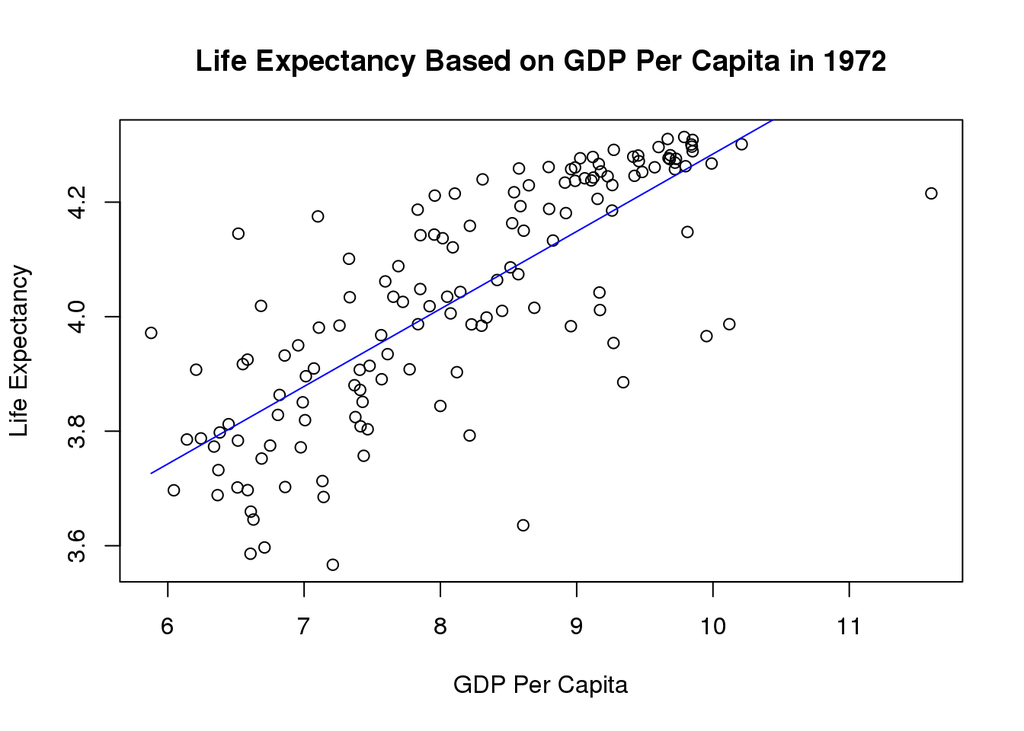

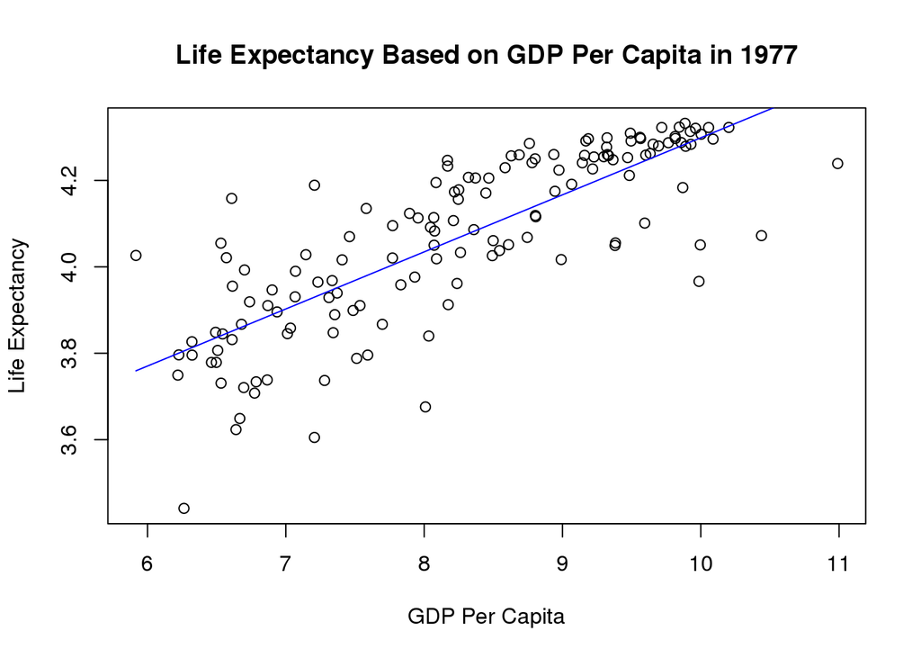

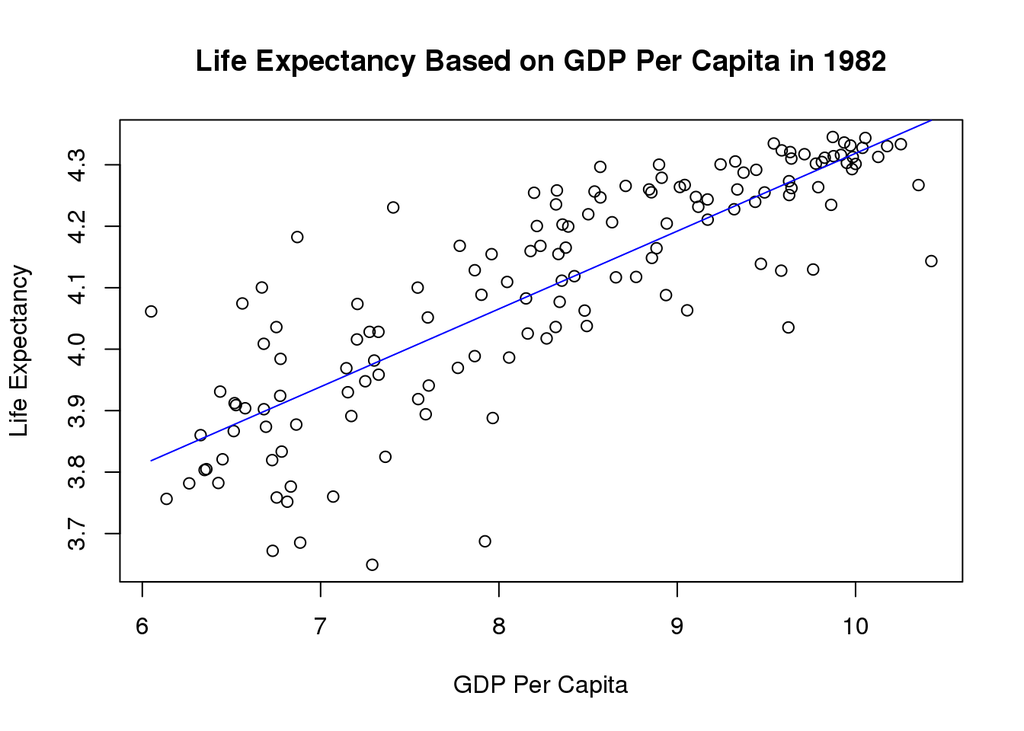

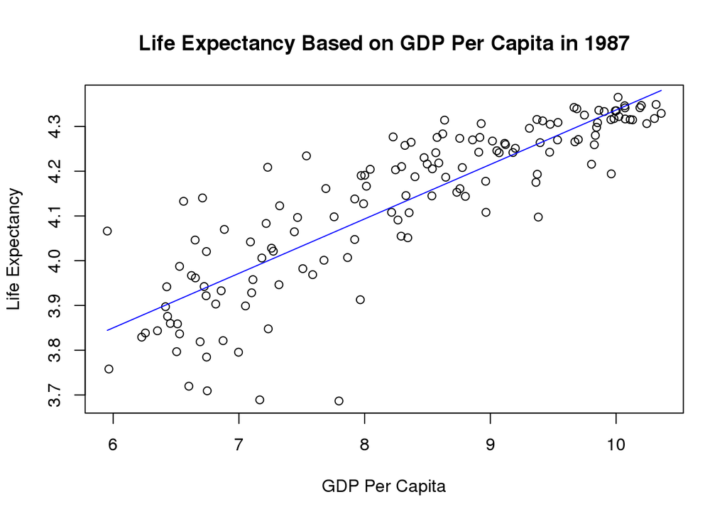

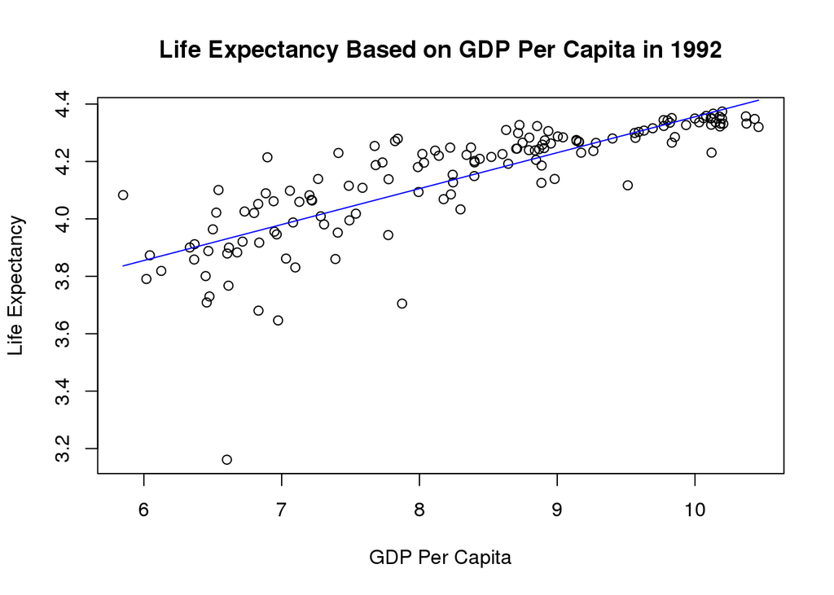

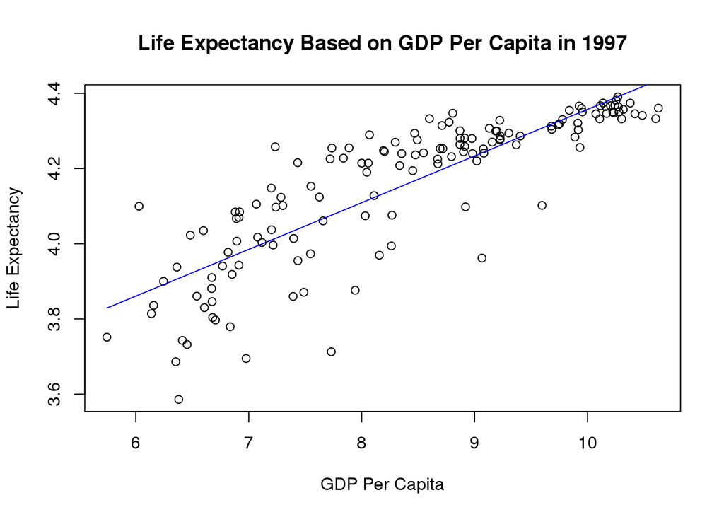

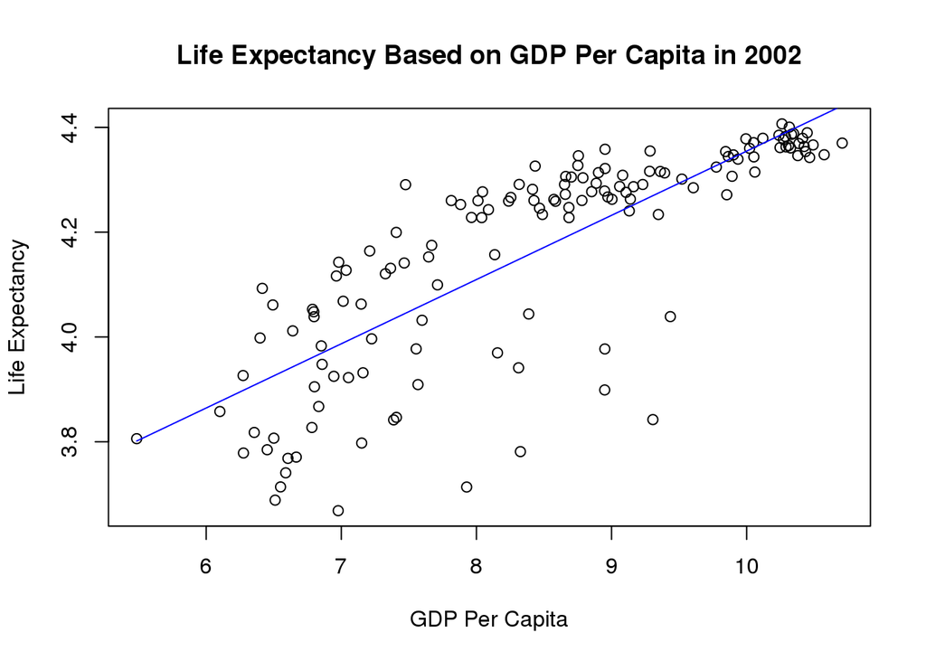

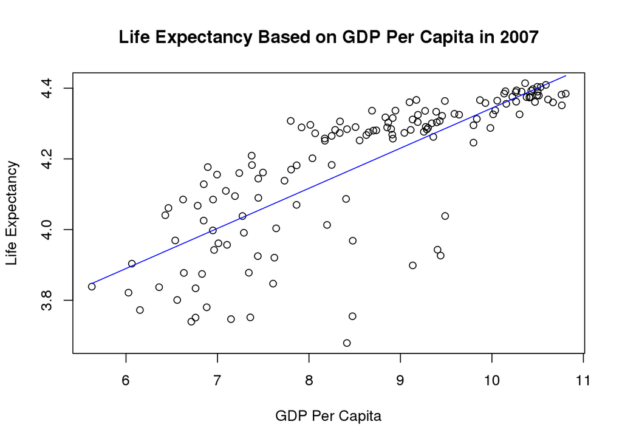

```r
for (i in unique(gapminder$year)){
  log_gdpPercap <- log(gapminder$gdpPercap[gapminder$year == i])
  log_le <- log(gapminder$lifeExp[gapminder$year == i])
  plot(log_le ~ log_gdpPercap, main = paste0("Life Expectancy Based on GDP Per Capita in ", i), xlab = "GDP Per Capita", ylab = "Life Expectancy")
  fit <- lm(log_le ~ log_gdpPercap)
  lines(log_gdpPercap, predict(fit), col = "blue")
}
```

2. Does the relationship between GDP per capita and life expectacy vary by continent? Make sure you divide the Americas into North and South America.

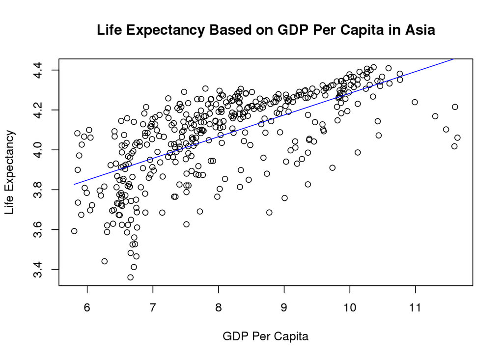

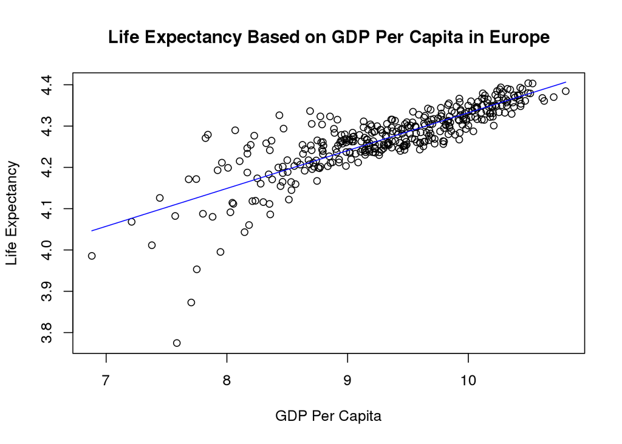

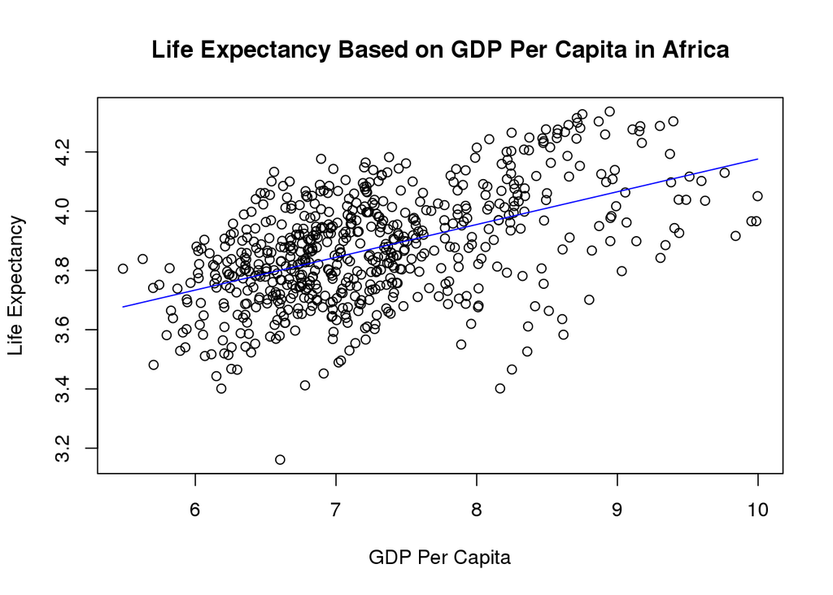

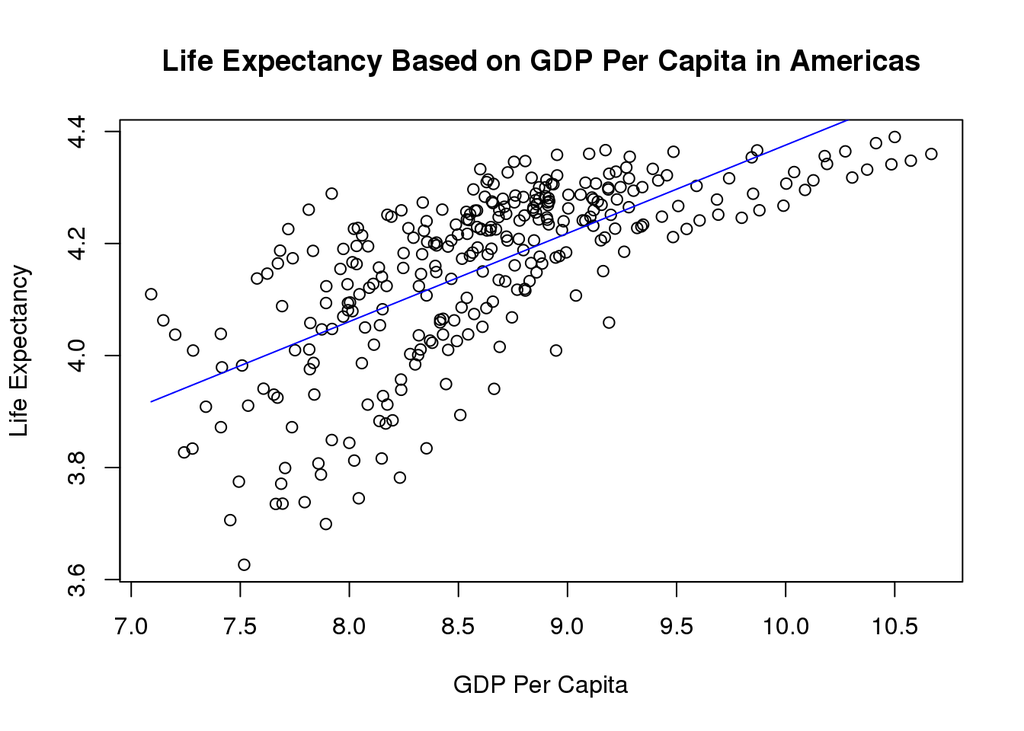

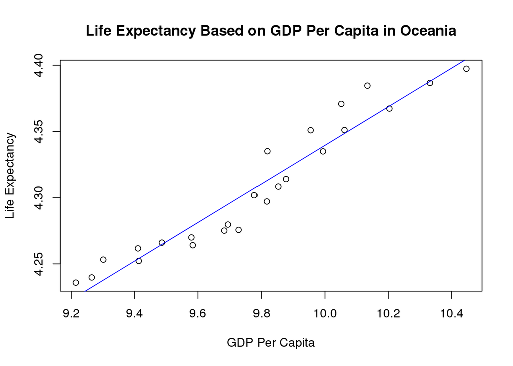

```r
year <- 2007
for (i in unique(gapminder$continent)){
  log_gdpPercap <- log(gapminder$gdpPercap[gapminder$continent == i])
  log_le <- log(gapminder$lifeExp[gapminder$continent == i])
  plot(log_le ~ log_gdpPercap, main = paste0("Life Expectancy Based on GDP Per Capita in ", i), xlab = "GDP Per Capita", ylab = "Life Expectancy")
  fit <- lm(log_le ~ log_gdpPercap)
  lines(log_gdpPercap, predict(fit), col = "blue")
}
```